# Find Complexes

Jeffrey Maurer

28 October 2018

# Setup

```r
library(Hotelling) # transformations
library(huge)      # graphing???
library(rsgcc)     # heatmap
library(gtools)    # invalid
library(funtimes)  # purity test
library(entropy)   #
library(ggplot2)   # plotting
library(pscl)      # hurdle and zeroinfl functions by Achim Zeileis
library(boot)      # not sure, something with zero inflated poisson
library(plyr)      # count in mutual information2
library(pROC)      # ROC curve
library(plyr)      # plot density/histograms
library(network)   # networks
library(GGally)    # display network
library(sna)       # sub to ggnet
library(scales)    # sub to ggnet
library(statnet.common) # see above
library(poweRlaw)  # produce and work with power laws
library(reshape2)  # melt subgraph into long format... provides an edgelist
library(RColorBrewer) # color graphic
library(magic)     # adiag function, add matrices together
library(lattice)   # levelplot
library(igraph)    # fitpowerlaw
knitr::opts_chunk$set(echo = TRUE)
#knitr::opts_knit$set(base.dir = '~/R/direct_contact-master/')
```

I went to github to find these files along with the script that looks like the researchers’ pipeline to help me.

I grabbed the uniprot IDs they used to train their ML model and converted them to Ensembl IDs, as the proteins are annotated in the map file with their ensembl ID. Interestingly, uniprot to ensembl isn’t 1-to-1, there are more ensembl IDs than the original number of Uniprot.

```r
data.smaller.smaller<-NULL
if (file.exists("data.RDS")) {
  data.smaller.smaller<-readRDS("data.RDS")
  data.ensembl <- read.table('Hs_all.prot_count_uniqpeps2_FDR0010.txt.map')
  UtoE <- read.csv("Uniprot_to_Ensembl_test_proteomics.csv", header=TRUE)
}else {
  data.raw <- read.table('Hs_all.prot_count_uniqpeps2_FDR0010.txt.gz')
  data.ensembl <- read.table('Hs_all.prot_count_uniqpeps2_FDR0010.txt.map')
  row.names(data.raw) <- t(data.ensembl)
  UtoE <- read.csv("Uniprot_to_Ensembl_test_proteomics.csv", header=TRUE)
}
```

Now to run the analysis. The original dataset with 15k proteins is too many to work with computationally when experimenting, and visualization will not have the proper granularity.

```r
if (!file.exists("data.RDS")){
  which.proteins <- row.names(data.raw) %in% t(UtoE[,2])
  data.smaller <- data.raw[which.proteins,]
  remove.proteins <- t(UtoE[,2]) %in% rownames(data.smaller)
  UtoE <- UtoE[remove.proteins,]
  data.smaller.num <- sapply(data.smaller, as.numeric)
  rownames(data.smaller.num) <- rownames(data.smaller)
  dim(data.smaller.num)
  # get the number of proteins with lesss than 50 data nonzero values
  sum(rowSums(data.smaller.num>0) < 50)
  data.smaller.smaller<-data.smaller.num[rowSums(data.smaller.num>0) > 50,]
  dim(data.smaller.smaller)
  # get the number of columns with less than 10 nonzero values
  sum(colSums(data.smaller.smaller>0)<10)
  data.smaller.smaller<- data.smaller.smaller[,colSums(data.smaller.smaller>0)>10]
  dim(data.smaller.smaller)
  saveRDS(object = data.smaller.smaller, file = "data.RDS")
} else {
  remove.proteins <- t(UtoE[,2]) %in% rownames(data.smaller.smaller)
  UtoE <- UtoE[remove.proteins,]
}
```

It would be nice to have a membership matrix. It shall be a matrix where both the rows and columns are the proteins, and the values are 1 or 0. If the two proteins are of the same complex, then that value is 1, otherwise 0.

```r
if (!file.exists("member.RDS"))
{
  protein_conversion <- UtoE[UtoE[,2] %in% rownames(data.smaller.smaller),]
  membership<-outer(X=1:nrow(protein_conversion),
                    Y=1:nrow(protein_conversion),
                    FUN = Vectorize(function(x,y) {
                      protein_conversion[x,3] == protein_conversion[y,3]
                    }))
  rownames(membership) = protein_conversion[,2]
  colnames(membership) = protein_conversion[,2]
  saveRDS(membership, "member.RDS")
} else {
  membership <- readRDS("member.RDS")
}
```

# Calculate Mutual Information

```r
data.smaller.smaller.binary <- matrix(as.integer(data.smaller.smaller > 0), nrow = nrow(data.smaller.smaller), ncol = ncol(data.smaller.smaller))
dim(data.smaller.smaller.binary)
```

```
## [1]  214 1340
```

```r
# x: vector of binary values
# y: vector of binary values
# output: mutual information between the two vectors
mutual_information <- function(x,y){
  if (length(x) != length(y)) {
    stop("Length of x and y not the same.")
  }
  # p(x,y)log_2(p(x,y)/(p(x)p(y)))
  # The cases are: p(x = 0, y = 0), p(x = 0, y = 1), p(x = 1, y = 0), p(x = 1, y = 1)
  xy <- x & y
  p_x <- sum(x) / length(x)
  p_y <- sum(y) / length(y)
  p_00 <- sum(as.integer((x == 0) & (y == 0))) / length(x)
  p_01 <- sum(as.integer((x == 0) & (y == 1))) / length(x)
  p_10 <- sum(as.integer((x == 1) & (y == 0))) / length(x)
  p_11 <- sum(as.integer((x == 1) & (y == 1))) / length(x)
  MI<-sum(
    p_00*log2(p_00/((1-p_x)*(1-p_y))),
    p_01*log2(p_01/((1-p_x)*p_y)),
    p_10*log2(p_10/(p_x*(1-p_y))),
    p_11*log2(p_11/(p_x*p_y)),
    na.rm = TRUE
  )
  return(MI)
}

# counts: vector of counts. The counts should be of each distinct state of a variable
shannon_entropy <- function(counts) {
  normalized_counts <- counts / sum(counts)
  normalized_nonzero_counts <- normalized_counts[normalized_counts != 0]
  H <- sum(normalized_nonzero_counts*log2(1/normalized_nonzero_counts))
  return(H)
}

# x: vector of binary values
# y: vector of binary values
# output: mutual information between the two vectors
mutual_information_shannon <- function(x,y){
  c_X = data.frame(table(x))[,2]
  c_Y = data.frame(table(y))[,2]
  require(plyr)
  c_XY = count(cbind(x, y))[,3]

  H_X = shannon_entropy(c_X)
  H_Y = shannon_entropy(c_Y)
  H_XY = shannon_entropy(c_XY)

  MI = H_X + H_Y - H_XY
  return(MI)
}
```

The functions work. In a section of code that I have hidden, I show that in a number of test cases, the two functions equal each other and give expected output. Now to calculate the MI between all proteins.

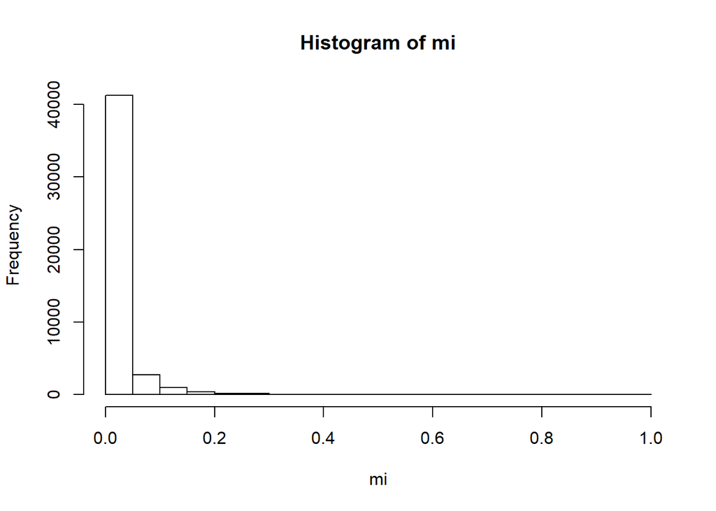

```r
# mat: binary matrix with rows being compared classes
# output: matrix with MIs of all rows
similarity_all <- function(mat, fun=mutual_information){
  outer(1:nrow(mat),
        1:nrow(mat),
        FUN = Vectorize(function(x,y) {
          fun(mat[x,], mat[y,])
        }))
}

mi<-similarity_all(data.smaller.smaller.binary)

# The binary matrix has no labels, it needs to be added back
rownames(mi) <- rownames(data.smaller.smaller)
colnames(mi) <- rownames(data.smaller.smaller)

saveRDS(mi, "MI_matrix.RDS")

hist(mi)
```

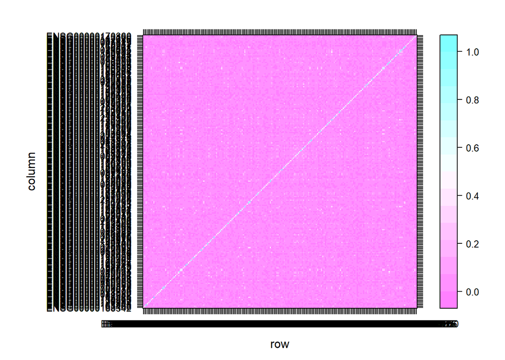

```r
levelplot(mi)
```

# Analyze MI Distribution

Are the MI values for membership different than in nonmembership? Let’s find out. We know what is in complex with what, so we can use that to separate the matrix into two sets: MI of membership and MI of noncmembership. Ideally, we would want these two distributions to not overlap very much.

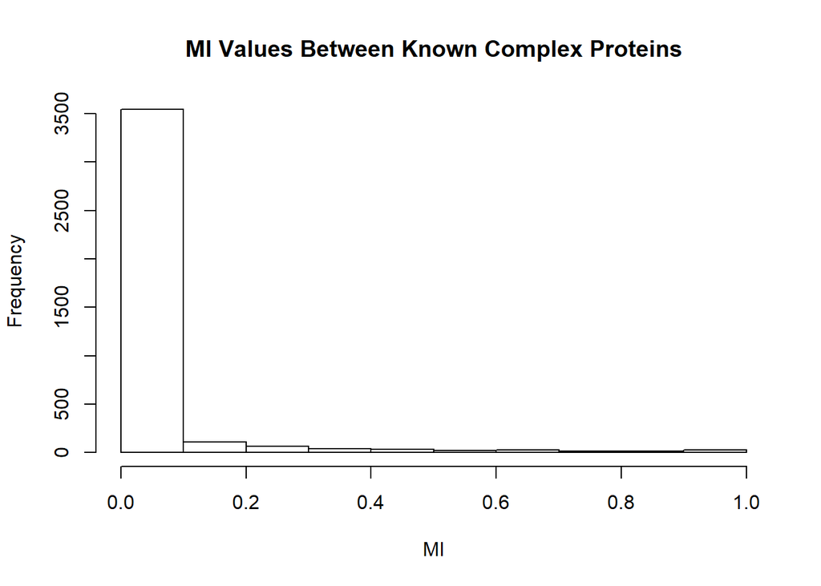

```r
# The values of membership
membership_mi <- mi[membership]
hist(membership_mi, xlab ="MI", ylab = "Frequency", main = "MI Values Between Known Complex Proteins")
```

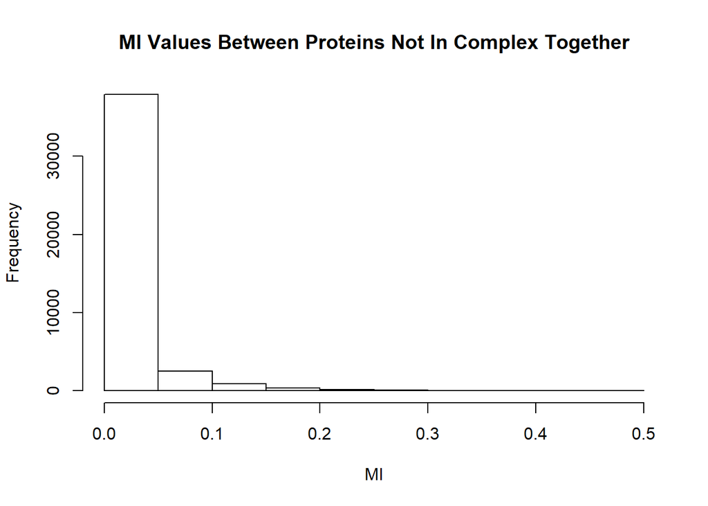

```r
# The values of nonmembership proteins
nonmembership_mi <- mi[!membership]
hist(nonmembership_mi, xlim = c(0,0.5), xlab ="MI", ylab = "Frequency", main = "MI Values Between Proteins Not In Complex Together")
```

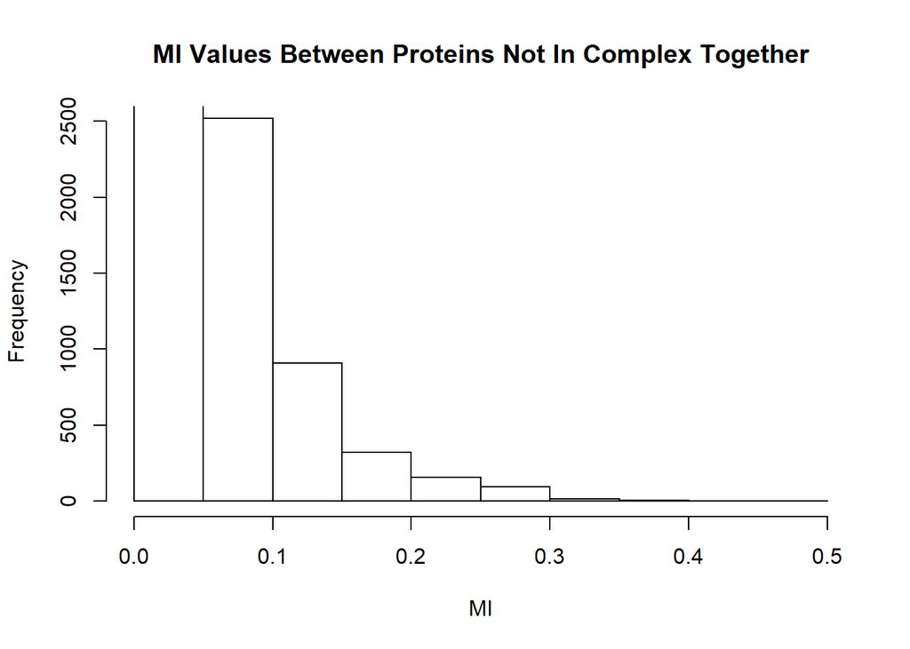

```r
# This is not so easy to see
hist(nonmembership_mi, ylim = c(0,2500), xlim = c(0,0.5), xlab ="MI", ylab = "Frequency", main = "MI Values Between Proteins Not In Complex Together")
```

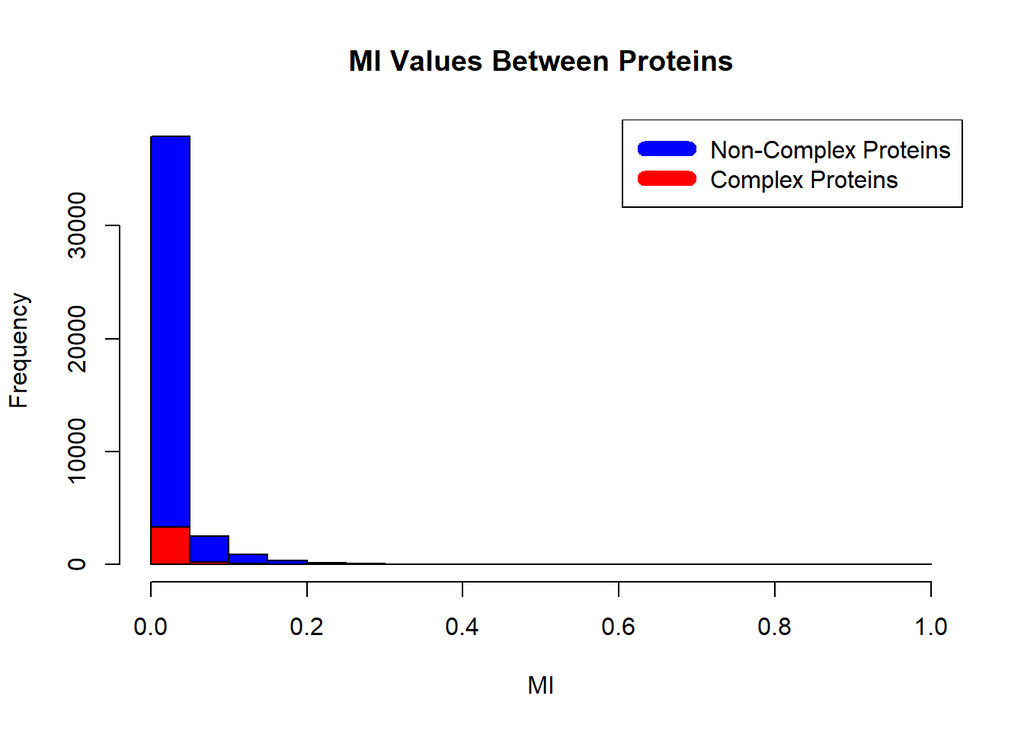

```r
# Overlay the plots
hist(nonmembership_mi, col='blue', xlim=c(0, 1), xlab ="MI", ylab = "Frequency", main = "MI Values Between Proteins")
hist(membership_mi, col='red', breaks = 20, add=T)
legend("topright", c("Non-Complex Proteins", "Complex Proteins"), col=c("blue", "red"), lwd=10)
```

```r
cat(paste("mean(membership_mi)", "mean(nonmembership_mi)", sep = " > "))
## mean(membership_mi) > mean(nonmembership_mi)
cat(paste(mean(membership_mi), mean(nonmembership_mi), sep = " > "))
## 0.0471701364181269 > 0.017714463477188
```

There is still not a very good separation between the two. In an portion of code I have hidden, I have included some statistics to show the separation between the two groups and the results seem mixed when compared to the histogram.

In some pieces of code that I have hidden, I test this same process’ results using two other similarity metrics between vectors, jaccard and sorenson. I continue the analysis using MI, however.

# Establish MI Cutoff for Future Analysis

Let’s find a good cutoff point. Most nonmembership values are really close to 0. Let’s see what type of cutoff works best. Ideally, we would like the distribution of the degrees of the nodes to resemble a power series.

```r
cutoff=0.05
interim_mi=similarity_all(data.smaller.smaller.binary)
diag(interim_mi)<-0
node_degrees = apply(interim_mi, 1, function(x) {sum(x > quantile(membership_mi, cutoff))})
# node of highest degree
node_degrees[node_degrees==max(node_degrees)]
# node of lowest degree
node_degrees[node_degrees==min(node_degrees)]
mi_ordered_values <- unique(sort(unlist(interim_mi)))
interim_mi[interim_mi < quantile(membership_mi, cutoff)] <- 0
mi_ordered_values <- mi_ordered_values[mi_ordered_values > quantile(membership_mi, cutoff)]
for (value in quantile(mi_ordered_values, prob = c(0, 0.50, 0.90, 0.99, 0.995, 0.999))) {
  cat(paste("cutoff ", value, '\n'))
  cat(paste("number of edges ", sum(interim_mi > value), '\n'))
  # graph it
  print(ggnet2(interim_mi))
  node_degrees = apply(interim_mi, 1, function(x) {sum(x > 0)})
  interim_mi[interim_mi < value] <- 0
  h<-hist(node_degrees)
  d.f <- data.frame(degree = log10(h$breaks[2:length(h$breaks)][h$counts>0]), frequency = log10(h$counts[h$counts>0]))
  line<-lm(frequency ~ degree, data = d.f)
  print(summary(line))
  plot( frequency ~ degree, data = d.f, main = "Log-log Plot", ylab = "Log10 Frequency", xlab = "Log10 Node Degrees")
  abline( h = 0, lty = 3, col = colors()[ 440 ] )
  abline(line)
  # fit_power_law(node_degrees[node_degrees>0], implementation="R.mle")
}
```

[output not shown]

# Find Dense Subgraphs

Here is my implementation of the algorithm. It takes less than 10 seconds to run, so it’s relatively fast.

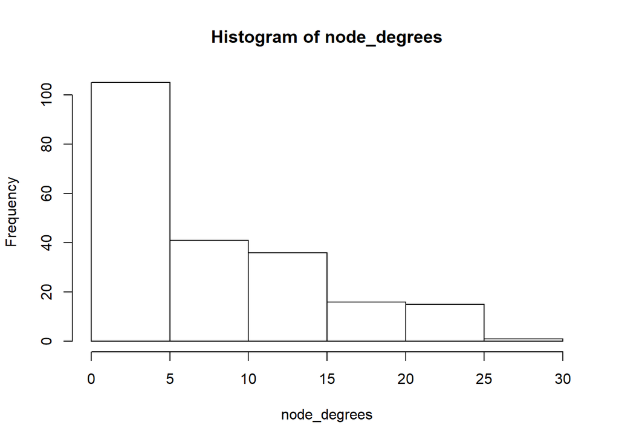

```r
mat=readRDS("MI_matrix.RDS")
diag(mat)<-0
mat[mat < 0.102] <- 0 #0.102 0.2339
node_degrees = apply(mat, 1, function(x) {sum(x > 0)})
h<-hist(node_degrees)
```

```r
d.f <- data.frame(degree = log(h$breaks[2:length(h$breaks)][h$counts>0]), frequency = log(h$counts[h$counts>0]))
line<-lm(frequency ~ degree, data = d.f)
summary(line)
```

```
##
## Call:
## lm(formula = frequency ~ degree, data = d.f)
##
## Residuals:
##          1          2          3          4          5          6
## -0.4497001 -0.0004469  0.6823881  0.4482111  0.8310372 -1.5114895
##
## Coefficients:
##             Estimate Std. Error t value Pr(>|t|)
## (Intercept)   8.3303     1.8345   4.541   0.0105 *
## degree       -2.0048     0.6616  -3.030   0.0388 *
## ---
## Signif. codes:  0 '***' 0.001 '**' 0.01 '*' 0.05 '.' 0.1 ' ' 1
##
## Residual standard error: 0.9803 on 4 degrees of freedom
## Multiple R-squared:  0.6966, Adjusted R-squared:  0.6207
## F-statistic: 9.183 on 1 and 4 DF,  p-value: 0.03877
```

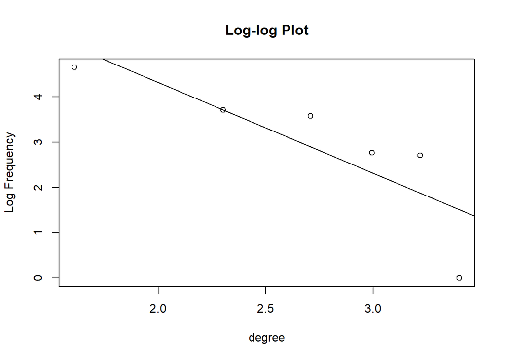

```r
plot( frequency ~ degree, data = d.f, main = "Log-log Plot", ylab = "Log Frequency")
abline(line)
```

```
##  [1] "ENSG00000136930" "ENSG00000159377" "ENSG00000130303"
##  [4] "ENSG00000010256" "ENSG00000169021" "ENSG00000008018"
##  [7] "ENSG00000126067" "ENSG00000198712" "ENSG00000140740"
## [10] "ENSG00000156467" "ENSG00000142507" "ENSG00000105364"
## [13] "ENSG00000101182" "ENSG00000198804" "ENSG00000180992"
## [16] "ENSG00000162736" "ENSG00000127184" "ENSG00000164919"
## [19] "ENSG00000099624" "ENSG00000135940" "ENSG00000178741"
## [22] "ENSG00000153956" "ENSG00000041357" "ENSG00000100804"
## [25] "ENSG00000100567" "ENSG00000131143" "ENSG00000129084"
## [28] "ENSG00000165629" "ENSG00000179091" "ENSG00000100902"
## [31] "ENSG00000106588" "ENSG00000152234" "ENSG00000143106"
```

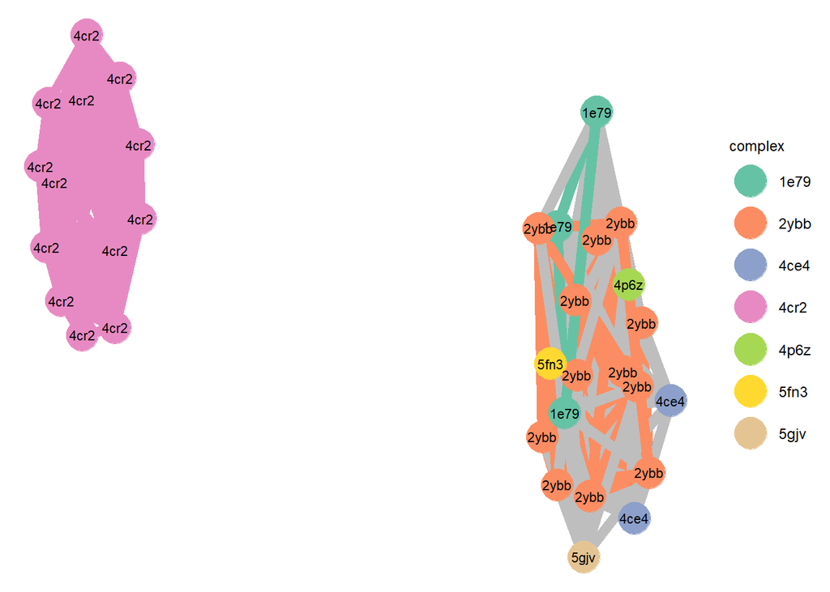

```
##  [1] "ENSG00000108671" "ENSG00000100519" "ENSG00000089009"
##  [4] "ENSG00000156482" "ENSG00000100316" "ENSG00000165916"
##  [7] "ENSG00000108298" "ENSG00000122406" "ENSG00000174748"
## [10] "ENSG00000161057" "ENSG00000131469" "ENSG00000125691"
## [13] "ENSG00000161016" "ENSG00000142937" "ENSG00000087191"
## [16] "ENSG00000137154" "ENSG00000197728" "ENSG00000105193"
## [19] "ENSG00000148303" "ENSG00000163636" "ENSG00000170889"
## [22] "ENSG00000136942" "ENSG00000175166" "ENSG00000231500"
## [25] "ENSG00000197170" "ENSG00000186468" "ENSG00000140988"
## [28] "ENSG00000147604" "ENSG00000089157" "ENSG00000130255"
## [31] "ENSG00000166441" "ENSG00000108344" "ENSG00000100764"
## [34] "ENSG00000173692" "ENSG00000013275"
```

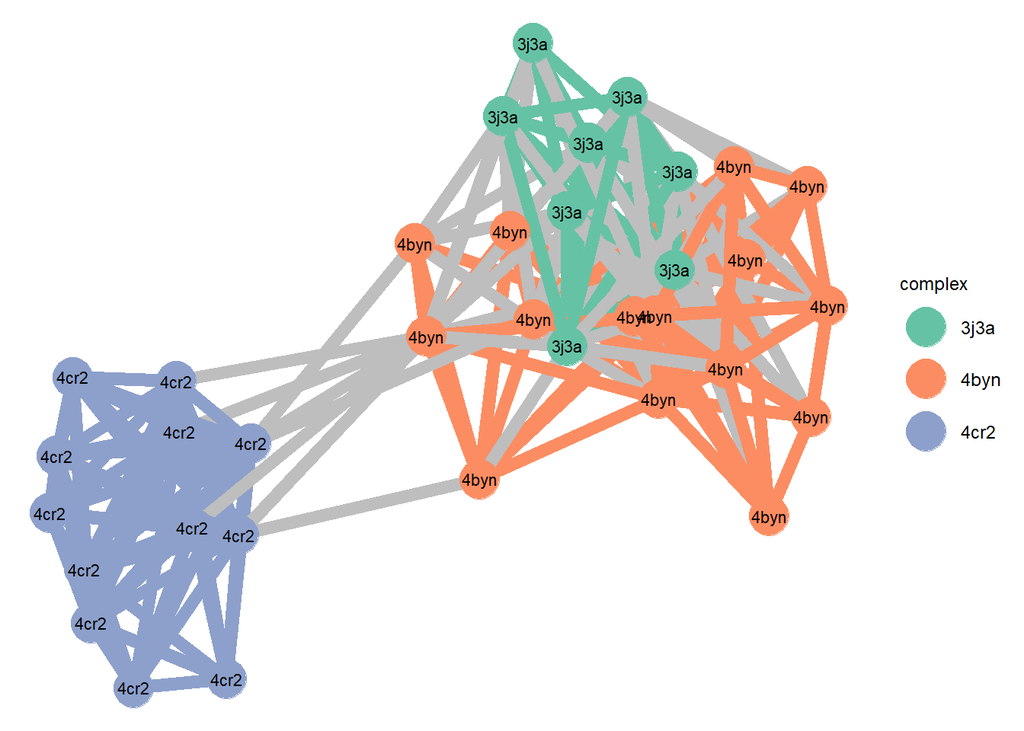

```
## [1] "ENSG00000163468" "ENSG00000115484" "ENSG00000120438" "ENSG00000166226"
## [5] "ENSG00000150753" "ENSG00000146731" "ENSG00000135624" "ENSG00000156261"
```

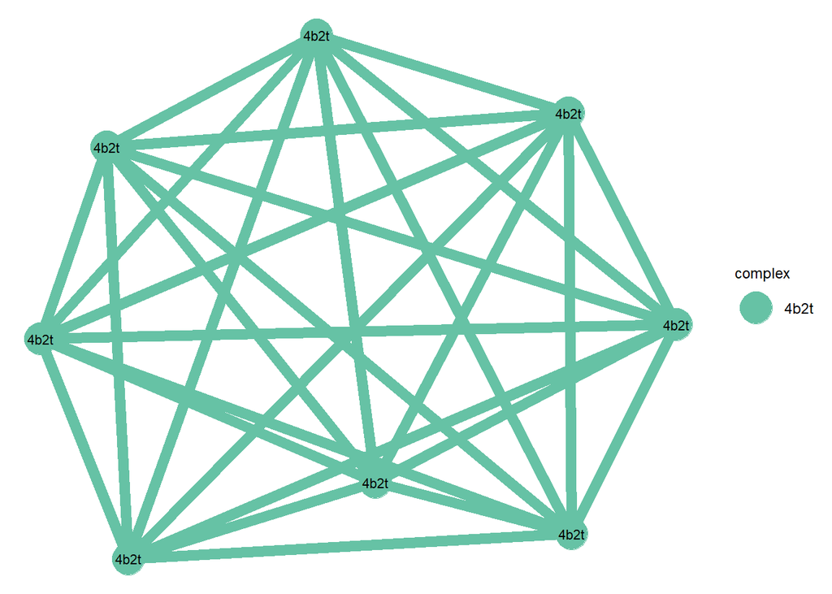

```
## [1] "ENSG00000163466" "ENSG00000115091" "ENSG00000138071" "ENSG00000241553"
## [5] "ENSG00000162704" "ENSG00000111229" "ENSG00000130429"
```

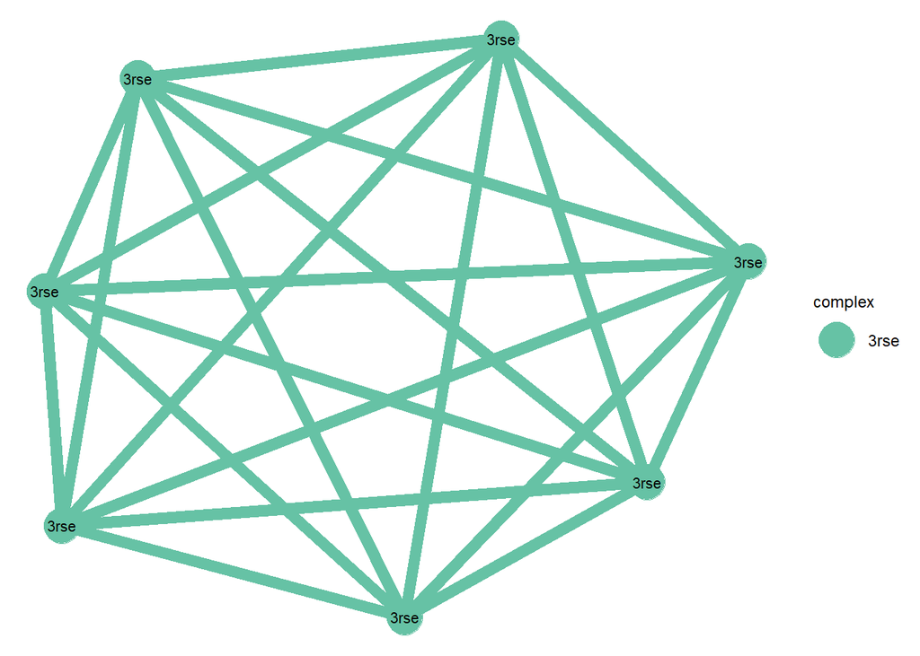

```
## [1] "ENSG00000075914" "ENSG00000223496" "ENSG00000120699" "ENSG00000123737"
## [5] "ENSG00000178896" "ENSG00000077348" "ENSG00000107371" "ENSG00000130713"
```

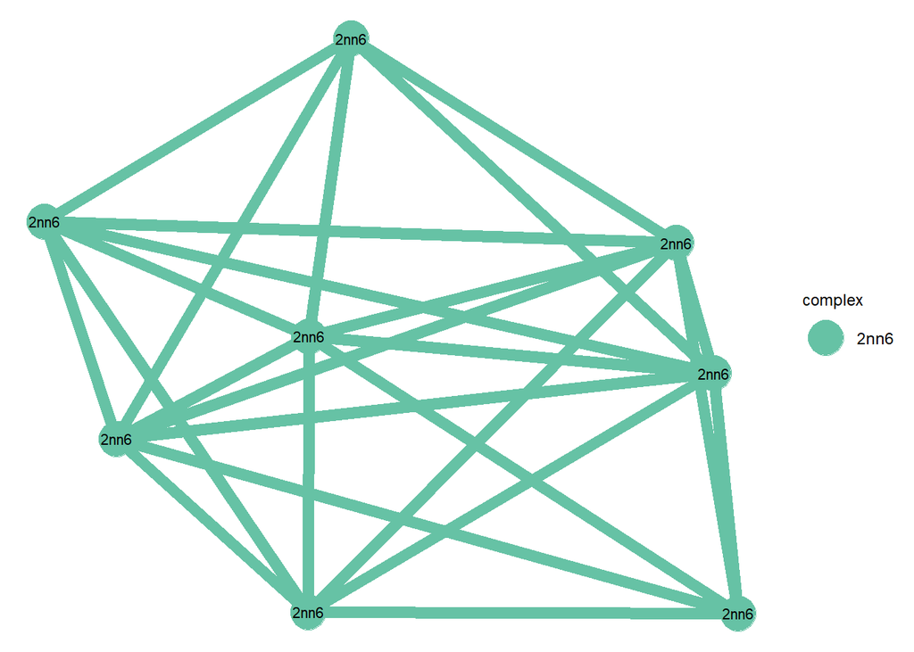

```
## [1] "ENSG00000104408" "ENSG00000147677" "ENSG00000107581" "ENSG00000100129"
## [5] "ENSG00000178982"
```

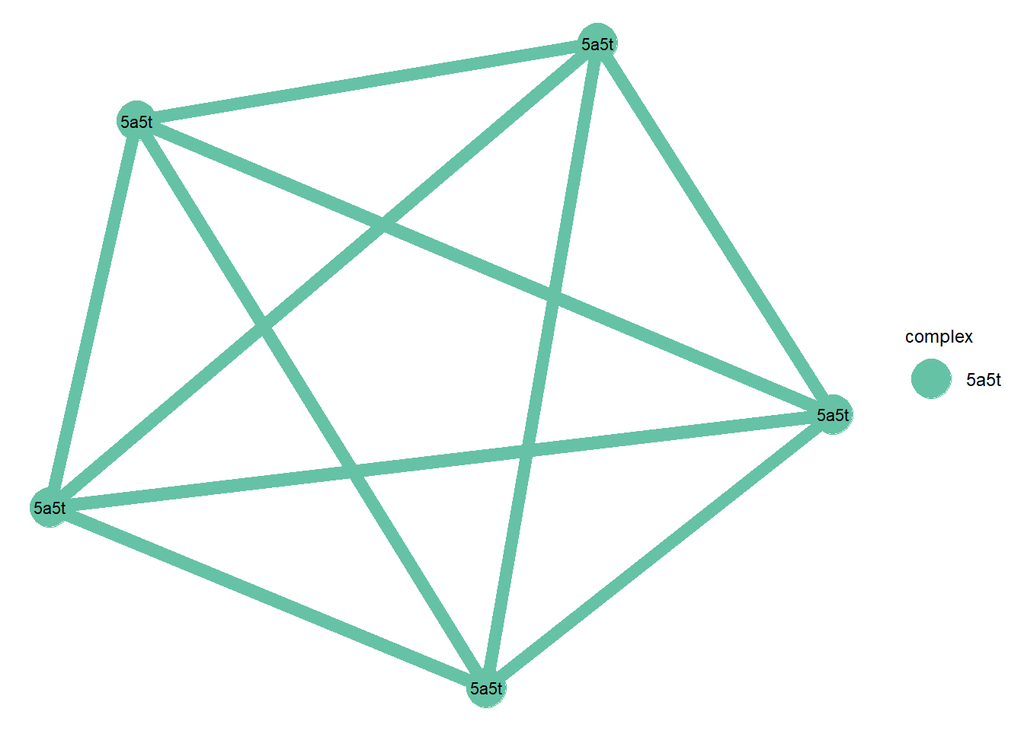

```
##  [1] "ENSG00000188342" "ENSG00000158042" "ENSG00000174231"
##  [4] "ENSG00000115364" "ENSG00000108883" "ENSG00000153767"
##  [7] "ENSG00000135900" "ENSG00000204316" "ENSG00000154719"
## [10] "ENSG00000125651"
```

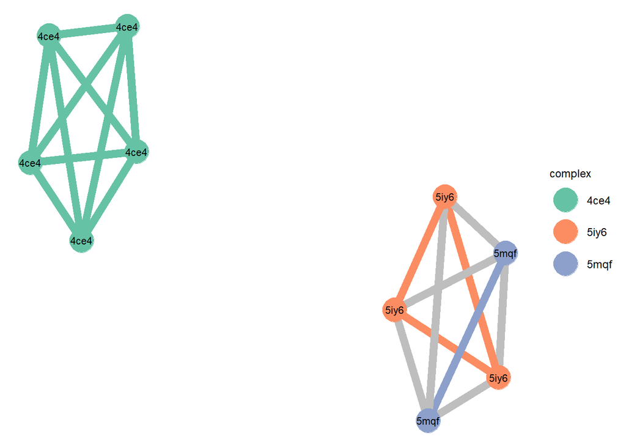

```
##  [1] "ENSG00000166200" "ENSG00000198612" "ENSG00000141030"
##  [4] "ENSG00000198034" "ENSG00000138663" "ENSG00000111652"
##  [7] "ENSG00000118181" "ENSG00000168090" "ENSG00000188846"
## [10] "ENSG00000145425"
```

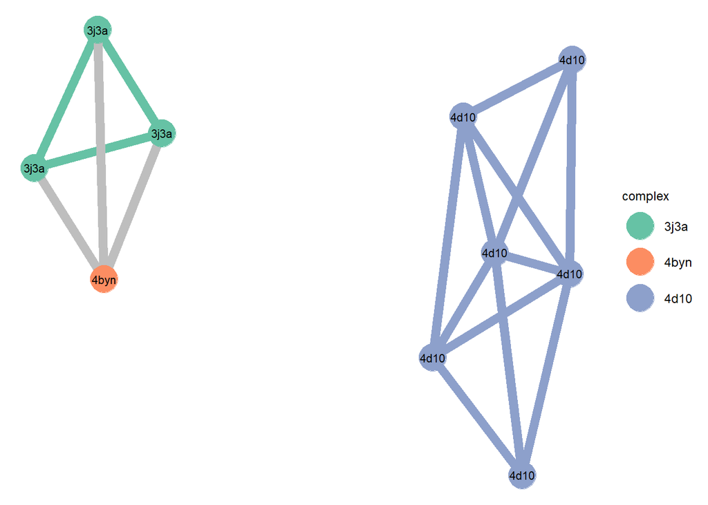

```
##  [1] "ENSG00000110955" "ENSG00000125743" "ENSG00000167088"
##  [4] "ENSG00000130332" "ENSG00000130520" "ENSG00000114391"
##  [7] "ENSG00000164587" "ENSG00000174444" "ENSG00000131876"
## [10] "ENSG00000125870" "ENSG00000164167" "ENSG00000100028"
## [13] "ENSG00000122026" "ENSG00000124614" "ENSG00000142676"
## [16] "ENSG00000170860"
```

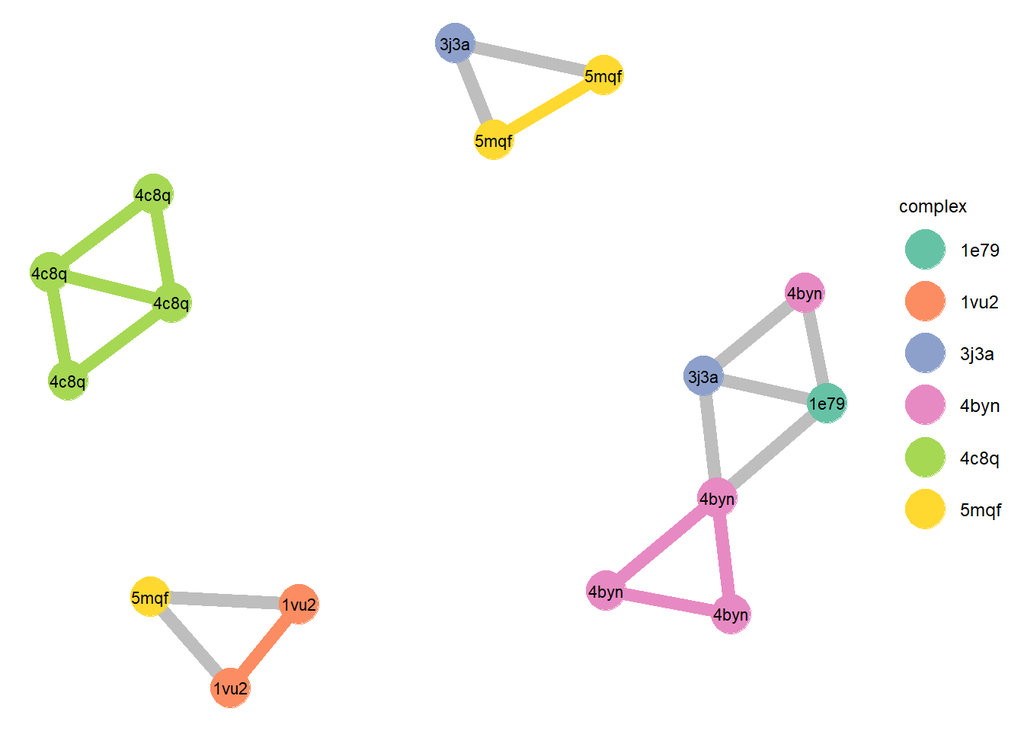

```
## [1] "ENSG00000116752" "ENSG00000110107" "ENSG00000168028" "ENSG00000096401"
## [5] "ENSG00000142864"
```

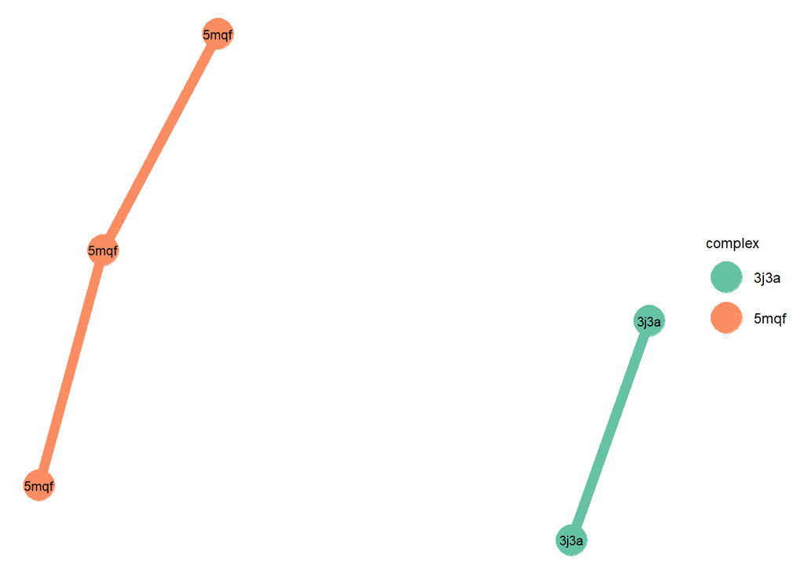

```
## [1] "ENSG00000103035" "ENSG00000115233" "ENSG00000185627"
```

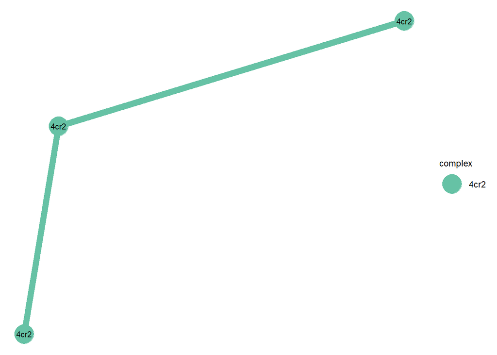

```
## [1] "ENSG00000134419" "ENSG00000149806"
```

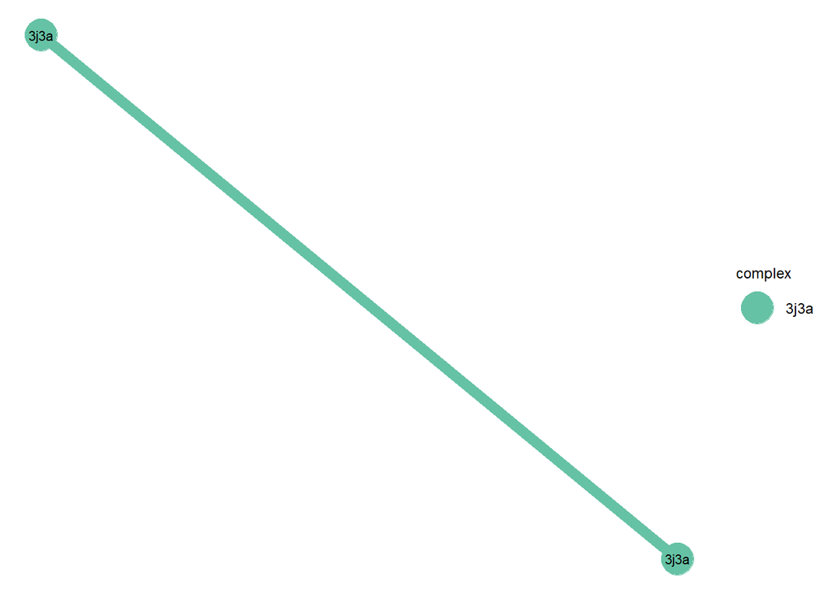

```
## [1] "ENSG00000198242" "ENSG00000115268" "ENSG00000172809" "ENSG00000149273"
## [5] "ENSG00000166747" "ENSG00000100280" "ENSG00000110700" "ENSG00000083845"
```

[2 more figures not shown]

```r
densests_matrix = NULL
k = 0
while(length(mat) > 1) {
  k <- k + 1
  this_subgraph<-mat
  # if the subgraph has no edges
  if (sum(this_subgraph > 0) == 0) {
    print(rownames(this_subgraph))
    print(ggnet2(this_subgraph))
    break
  }
  subgraphs = list()
  for (i in 1:(nrow(mat)-2)) {
    node_degrees = apply(this_subgraph, 1, function(x) {sum(x > 0)})
    this_subgraph <- this_subgraph[-which.min(node_degrees), -which.min(node_degrees)]
    subgraphs[[i]] <- this_subgraph
  }
  densities <- lapply(X = subgraphs, FUN = function (x) {sum(x)/nrow(x)})
  densest <- subgraphs[[which.max(densities)]]
  drownames <- rownames(densest)
  print(drownames)
  net = network(densest*6, directed = FALSE, ignore.eval = FALSE, names.eval = "MI")
  net %v% "complex" <- as.character(UtoE$membership[match(drownames, UtoE$Ensembl)])
  nnet<-matrix(0, nrow(densest), nrow(densest))
  for (i in 1:nrow(densest)){
    for (j in 1:nrow(densest)){
      nnet[i,j] = ifelse(UtoE$membership[UtoE$Ensembl %in% rownames(densest)[i]]==UtoE$membership[UtoE$Ensembl %in% colnames(densest)[j]],
                         toupper(as.character(UtoE$membership[UtoE$Ensembl %in% colnames(densest)[j]])),
                         "zzzzwrong") # if the edge is between proteins of different complexes
    }
  }
  num_colors<-length(table(nnet))
  map_color<-data.frame(membership=rownames(table(nnet)), color=c(brewer.pal(max(3, num_colors),"Set2")[1:(num_colors-1)], "#BEBEBE")) # 3 is min num f colors
  edge_colors <- map_color[match(nnet[lower.tri(nnet)][densest[lower.tri(densest)]>0], map_color$membership),2]
  print(ggnet2(net,
               color = "complex",
               palette = "Set2",
               label = "complex",
               label.size = 2.9,
               edge.size = 3,
               edge.color = as.character(edge_colors)))
  mat <- mat[!(rownames(mat) %in% drownames), !(rownames(mat) %in% drownames)]
  new_names <- c(rownames(densests_matrix), drownames)
  if (is.null(densests_matrix)) {
    densests_matrix <- densest
  } else {
    densests_matrix <- adiag(densests_matrix, densest)
    rownames(densests_matrix) <- new_names
    colnames(densests_matrix) <- new_names
  }
}
```

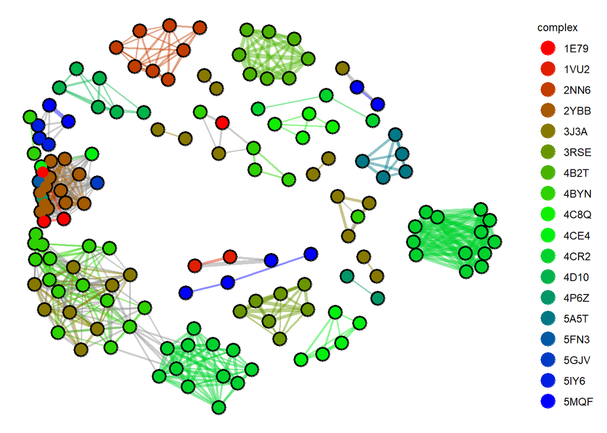

```r
densest <- densests_matrix
drownames <- rownames(densest)
net = network(densest*6, directed = FALSE, ignore.eval = FALSE, names.eval = "MI")
net %v% "complex" <- toupper(as.character(UtoE$membership[match(drownames, UtoE$Ensembl)]))
nnet<-matrix(0, nrow(densest), nrow(densest))
for (i in 1:nrow(densest)){
  for (j in 1:nrow(densest)){
    nnet[i,j] = ifelse(UtoE$membership[UtoE$Ensembl %in% rownames(densest)[i]]==UtoE$membership[UtoE$Ensembl %in% colnames(densest)[j]],
                       as.character(UtoE$membership[UtoE$Ensembl %in% colnames(densest)[j]]),
                       "zzzzwrong") # if the edge is between proteins of different complexes
  }
}
colors<-colorRampPalette(colors = c("red", "green", "blue"))
num_colors <- length(table(nnet))
map_color<-data.frame(membership=rownames(table(nnet)), color=c(colors(num_colors-1), "#8F8F8F"))
edge_colors <- map_color[match(nnet[lower.tri(nnet)][densest[lower.tri(densest)]>0], map_color$membership),2]
my_palette<-colors(num_colors-1)
complex_names <- rownames(table(net %v% "complex"))
names(my_palette) <- complex_names
ggnet2(net,
       color = "complex",
       palette = my_palette,
       node.size = 5.5,
       layout.par = list(repulse.rad = 5000, niter = 5000), # may be slightly smaller than needed to prevent overlap
       edge.size = "MI",
       edge.color = as.character(edge_colors),
       edge.alpha = 0.45) + # seems like a good alpha value
       geom_point(aes(color = color), size = 5.5, color = "black") +
       geom_point(aes(color = color), size = 4)
```